## Report: act_report

- Create a **250-word-minimum written report** called "act_report.pdf" or "act_report.html" that communicates the insights and displays the visualization(s) produced from your wrangled data. This is to be framed as an external document, like a blog post or magazine article, for example.

# Insight into WeRateDogs

## By: Ayomide Adenuga

WeRateDogs is a twitter account that is popular for rating dogs humorously from the pictures submitted by its followers, according to the information on its twitter bio. It is created in November 2015, currently it has over 9 million followers. Twitter downloaded and sent this account data to Udacity so Udacity’s students can work on this data in their nano degree. WeRateDogs has its own way of classifying dogs, namely: Puppers, Puppos, Doggos, and Floofers. The Puppies are Puppers, while the older Puppies are Puppos, the older Puppos are Doggos, and the Floofers are the hairy dogs.

We decided to researched about:

### Insight 1

After cleaning it was revealed that Iphone is the device through with most tweets are sent, The summary of the device and the number of tweets sent from each is summarized below:

- Twitter for iPhone **23804 times**
- Make a Scene **364 times**
- Twitter Web Client **348 times**
- TweetDeck **132 times**

### Insight 2

- `Sunglass` has the highest ratings of 893/10
- `Space_Shuttle` has the lowest ratings of 0/10

### Insight 3

- The most common dogs are Golden_Retriever and Labrador_Retriever

### Visualization

- There is a right-upward trend between Retweets and Favorites tweet, meaning High numbers of Retweets and Favorite goes together

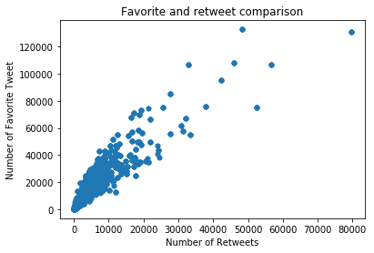